# Heat Index-CVD

## 2021 - Heat Index

### CVD DALY attributable to high average Heat Index in 2021

#### As table

**Click here to view/hide the code**

```r
rmarkdown::paged_table(paf_economydata_formapviz)
```

| state | Year | mean_25 | mean_975 | variation_25 | variation_975 | CVD_DALY | paf_daly_avghi25 | paf_daly_avghi975 | paf_daly_var25 | paf_daly_var975 |
| --- | --- | --- | --- | --- | --- | --- | --- | --- | --- | --- |
| Andhra Pradesh | 2021 | 12.929694 | 17.985096 | 3.513406 | 9.044478 | 3173432.14 | 24611 | 45133 | 20470 | -14999 |
| Arunachal Pradesh | 2021 | -2.651507 | 9.458191 | 2.904721 | 11.320833 | 37202.38 | 289 | 529 | 240 | -176 |
| Assam | 2021 | 5.405469 | 15.239260 | 3.463946 | 11.079477 | 1543622.66 | 11971 | 21954 | 9957 | -7296 |
| Bihar | 2021 | 5.718447 | 17.845148 | 3.229865 | 12.225634 | 4786894.91 | 37124 | 68080 | 30878 | -22625 |
| Chhattisgarh | 2021 | 9.594551 | 17.869818 | 3.334171 | 12.584013 | 1997059.19 | 15488 | 28403 | 12882 | -9439 |
| Delhi | 2021 | 4.531864 | 20.159675 | 3.200356 | 13.336422 | 772071.99 | 5988 | 10981 | 4980 | -3649 |
| Goa | 2021 | 12.709403 | 17.738523 | 2.209821 | 9.620011 | 93579.69 | 726 | 1331 | 604 | -442 |
| Gujarat | 2021 | 10.262850 | 18.571892 | 3.446968 | 10.575793 | 4542629.03 | 35229 | 64606 | 29302 | -21470 |
| Haryana | 2021 | 4.283890 | 19.854164 | 3.595078 | 13.045479 | 1429296.67 | 11085 | 20328 | 9220 | -6755 |
| Himachal Pradesh | 2021 | -8.922849 | 9.002536 | 3.941562 | 13.042087 | 376691.28 | 2921 | 5357 | 2430 | -1780 |

[output cut: 19 more lines]

#### As bar charts

**Click here to view/hide the code**

Figure 3: CVD DALY attributable to high average Heat Index 2021

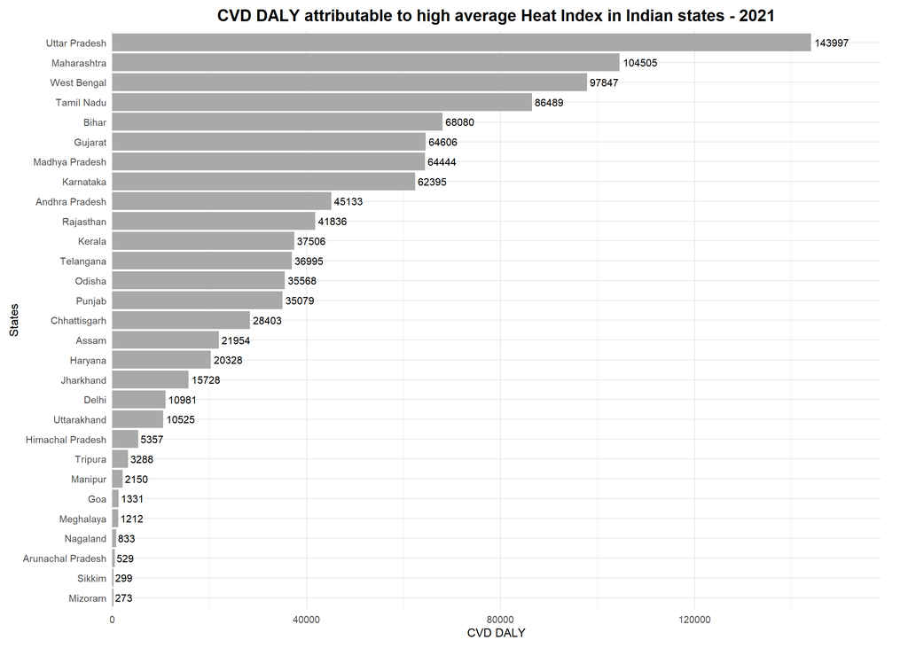

```r
paf_economydata_formapviz |>
  ggplot(
aes(x = reorder(state,paf_daly_avghi975), y = paf_daly_avghi975)) +

  # Bars
  geom_bar(stat = "identity", fill = "darkgrey") +

  # Labels: absolute DALY numbers at tail (outside bars)
  geom_text(aes(label = round(paf_daly_avghi975)),
            hjust = -0.1, size = 4, color = "black") +

  # Flip for horizontal bars
  coord_flip(clip = "off") +  # allow labels beyond plot area

  labs(title="CVD DALY attributable to high average Heat Index in Indian states - 2021",
       x="States",
       y="CVD DALY") +

  scale_y_continuous(expand = expansion(mult = c(0, 0.1))) +  # add space for text on right

  theme_minimal(base_size = 14) +
  theme(
    plot.title = element_text(hjust = 0.5, size = 18, face = "bold"),
    axis.text.y = element_text(size = 11),
    axis.text.x = element_text(size = 11),
    axis.title.x = element_text(size = 13),
    axis.title.y = element_text(size = 13),
    plot.margin = margin(10, 30, 10, 10)  # top, right, bottom, left
  )
```

Figure 3 *Cardiovascular disease (CVD) disability-adjusted life years (DALYs) attributable to high average Heat Index across Indian states in 2021. Values represent absolute DALY counts (not standardized per 100,000 population) derived from the GBD uncorrected dataset. Attributable DALYs were estimated by applying population-attributable fractions (PAFs), based on exposure–response relationships, to total CVD DALYs. The figure highlights marked inter-state variation, with Uttar Pradesh, Maharashtra, and West Bengal bearing the highest Heat Index-linked disease burden.*

#### As India maps

**Click here to view/hide the code**

```r
library(sf)
library(tidyverse)

india <- readRDS(here::here("data",
                            "spatial_files",
                            "India_states.rds"))
india <- india |>
        rename(state = NAME_1) |>
        # recode orissa as odisha
        mutate(state = recode(state, "Orissa" = "Odisha")) |>
# recode uttaranchal as uttarakhand
        mutate(state = recode(state, "Uttaranchal" = "Uttarakhand"))


# combine paf_data_formapviz with india based on state variable
india_paf_economy <- india |>
  left_join(paf_economydata_formapviz, by = "state")
india_paf_economy <- india_paf_economy |>
        mutate(centroid = st_centroid(geometry)) %>%
  mutate(x = st_coordinates(centroid)[,1],
         y = st_coordinates(centroid)[,2])
```

**Click here to view/hide the code**

Figure 4: CVD burden attributable to high average Heat Index in Indian states

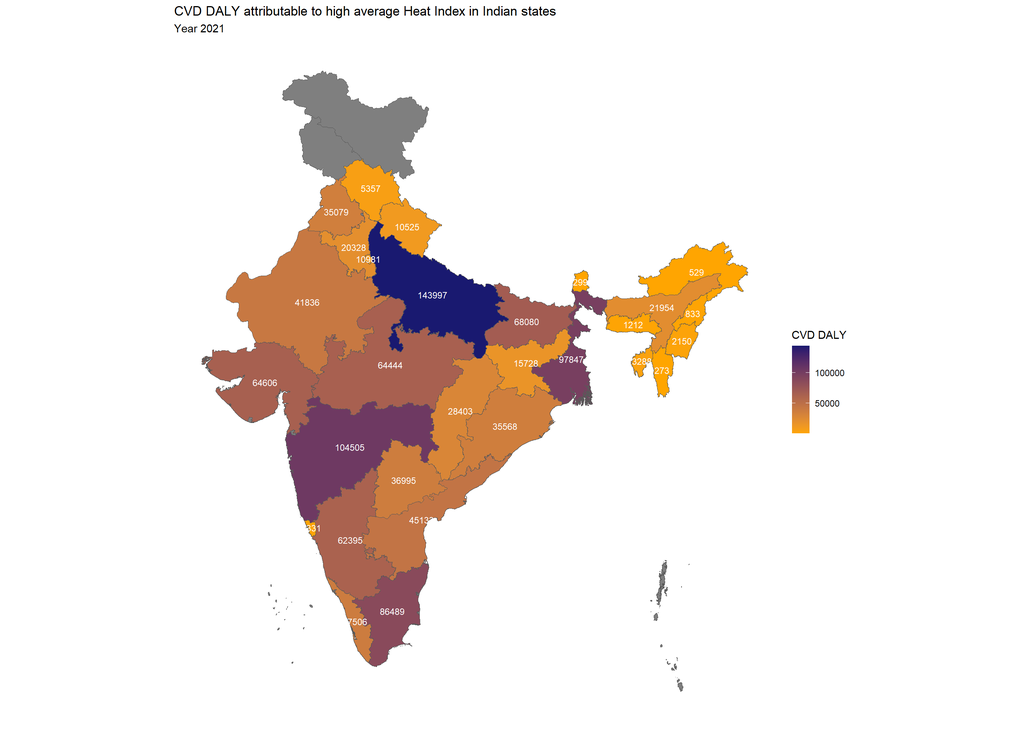

```r
# DALY map
india_paf_economy |>
  ggplot() +
  geom_sf(aes(fill = paf_daly_avghi975)) +
  scale_fill_gradient(low = "orange", high = "midnightblue") +
  # Add paf on the states as text with x and y coordinates
  geom_text(aes(x = x, y = y, label = paf_daly_avghi975), size = 3, color = "white") +
  labs(fill = "CVD DALY",
       title = "CVD DALY attributable to high average Heat Index in Indian states",
       subtitle = "Year 2021") +
  theme_classic() +
  # Make x-axis and y-axis blank
  theme(axis.text.x = element_blank(),
        axis.text.y = element_blank(),
        axis.title.x = element_blank(),
        axis.title.y = element_blank(),
        axis.ticks = element_blank(),
        axis.line = element_blank())
```

Figure 4 *State-wise distribution of cardiovascular disease (CVD) disability-adjusted life years (DALYs) attributable to high average Heat Index in India, 2021. Absolute DALY counts were calculated using uncorrected Global Burden of Disease (GBD) 2021 data and population-attributable fractions (PAFs) based on exposure–response estimates. Values are presented as total DALYs (not standardized per 100,000 population). States are color-coded according to the magnitude of Heat Index-attributable CVD DALYs, with darker shades indicating higher burden. Uttar Pradesh, Maharashtra, and West Bengal exhibited the highest values, reflecting substantial climate-linked health impacts.*

### Total economic burden attributable to high average Heat Index - 2021

**Click here to view/hide the code**

Figure 5: Total economic burden attributable to high average Heat Index 2021

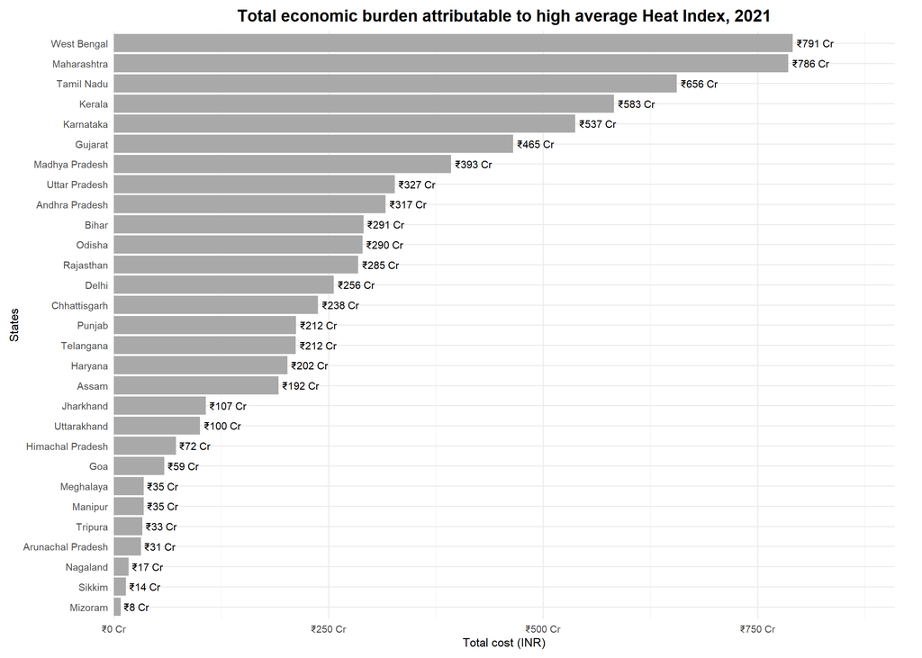

```r
#  visualize total econ burden in all states by bar charts



total_daly_costcal_2021 |>
  drop_na(totalcost_avgheatindexhigh) |>
  mutate(totalcost_avgheatindexhigh=round(totalcost_avgheatindexhigh,0)) |>
  ggplot(aes(x = reorder(State, totalcost_avgheatindexhigh),
             y = totalcost_avgheatindexhigh)) +

  # Bar plot
  geom_bar(stat = "identity", fill = "darkgrey") +

  # Label at the tail end, just outside the bar
  geom_text(aes(label = paste0("\u20B9", round(totalcost_avgheatindexhigh / 1e7, 0), " Cr")),
            hjust = -0.1, color = "black", size = 4) +

  # Flip coordinates
  coord_flip(clip = "off") +  # allows text beyond plotting area

  # Titles and axis labels
  labs(
    title = "Total economic burden attributable to high average Heat Index, 2021",
    x = "States",
    y = "Total cost (INR)"
  ) +

  # y-axis in crores
  scale_y_continuous(
    labels = function(x) paste0("\u20B9", x / 1e7, " Cr"),
    expand = expansion(mult = c(0, 0.15))  # space for tail labels
  ) +

  # Aesthetic theme
  theme_minimal(base_size = 14) +
  theme(
    plot.title = element_text(hjust = 0.5, size = 18, face = "bold"),
    axis.text.y = element_text(size = 11),
    axis.text.x = element_text(size = 11),
    axis.title.x = element_text(size = 13),
    axis.title.y = element_text(size = 13),
    plot.margin = margin(10, 30, 10, 10)  # top, right, bottom, left
  )
```

Figure 5 *Total economic burden attributable to high average Heat Index across Indian states in 2021. This figure displays state-wise estimates of total economic burden (in Indian Rupees) linked to cardiovascular disease (CVD) disability-adjusted life years (DALYs) attributed to high average Heat Index. The economic burden was computed by multiplying absolute attributable DALY counts (from the GBD uncorrected dataset) with the estimated cost per DALY for 2021. The highest costs were observed in West Bengal, Maharashtra, and Tamil Nadu, reflecting both high DALY burden and high cost-per-case in these states.*

**Click here to view/hide the code**

```r
totaleconburden_2021_hi <- total_daly_costcal_2021 |>
  drop_na(totalcost_avgheatindexhigh) |>
  summarise(totaleconburden = sum(totalcost_avgheatindexhigh, na.rm = TRUE))
```

**India Total Economic Burden in 2021 due to High Average Heat Index**

There was a total economic burden of **₹75 424 954 818** in 2021 due to high average Heat Index across Indian states. This estimate is based on the **DALY** attributable to high average Heat Index and the cost per DALY.

## 2030 Projections - Heat Index

### CVD DALY attributable to high average Heat Index in 2030

**Click here to view/hide the code**

```r
# import data from output/total-econ-burden-projections using here

absDALY2030 <- readRDS(here::here("output","daly-projections","absDALY2030_hi.rds"))
```

#### As table

**Click here to view/hide the code**

```r
absDALY2030 |>
  dplyr::select(state,Year,paf_daly_proj2030_avg975hi) |>
rmarkdown::paged_table()
```

| state | Year | paf_daly_proj2030_avg975hi |
| --- | --- | --- |
| Andhra Pradesh | 2030 | 51044 |
| Arunachal Pradesh | 2030 | 605 |
| Assam | 2030 | 21611 |
| Bihar | 2030 | 65963 |
| Chhattisgarh | 2030 | 29151 |
| Delhi | 2030 | 10491 |
| Goa | 2030 | 1499 |
| Gujarat | 2030 | 80194 |
| Haryana | 2030 | 17360 |
| Himachal Pradesh | 2030 | 6182 |

[output cut: 21 more lines]

#### As bar charts

**Click here to view/hide the code**

Figure 6: Projected CVD DALY attributable to high average Heat Index 2030

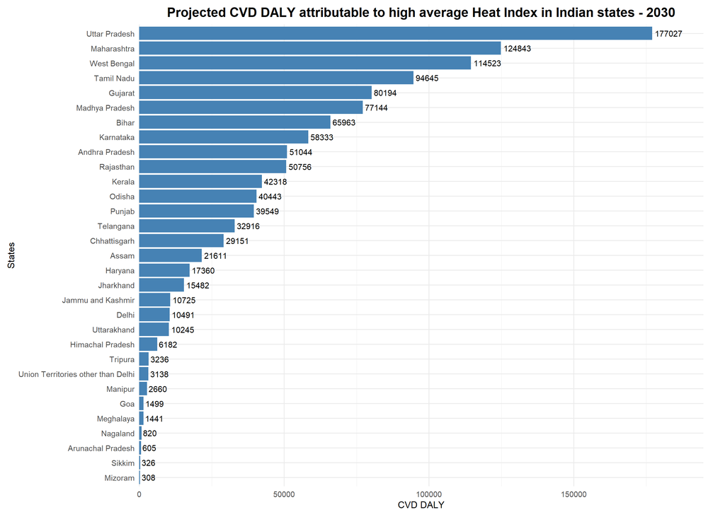

```r
absDALY2030 |>
  ggplot(aes(x = reorder(state, paf_daly_proj2030_avg975hi),
             y = paf_daly_proj2030_avg975hi)) +

  # Bars
  geom_bar(stat = "identity", fill = "steelblue") +

  # Labels: absolute DALY numbers at tail (outside bars)
  geom_text(aes(label = round(paf_daly_proj2030_avg975hi)),
            hjust = -0.1, size = 4, color = "black") +

  # Flip for horizontal bars
  coord_flip(clip = "off") +  # allow labels beyond plot area

  # Labels and theme
  labs(
    title = "Projected CVD DALY attributable to high average Heat Index in Indian states - 2030",
    x = "States",
    y = "CVD DALY"
  ) +

  scale_y_continuous(expand = expansion(mult = c(0, 0.1))) +  # add space for text on right

  theme_minimal(base_size = 14) +
  theme(
    plot.title = element_text(hjust = 0.5, size = 18, face = "bold"),
    axis.text.y = element_text(size = 11),
    axis.text.x = element_text(size = 11),
    axis.title.x = element_text(size = 13),
    axis.title.y = element_text(size = 13),
    plot.margin = margin(10, 30, 10, 10)  # top, right, bottom, left
  )
```

Figure 6 *Projected cardiovascular disease (CVD) disability-adjusted life years (DALYs) attributable to high average Heat Index across Indian states in 2030. Values represent absolute DALY counts (not standardized per 100,000 population) derived from the GBD uncorrected dataset. Attributable DALYs were estimated by applying population-attributable fractions (PAFs), based on exposure–response relationships, to total CVD DALYs. The figure highlights marked inter-state variation, with Uttar Pradesh, Maharashtra, and West Bengal bearing the highest Heat Index-linked disease burden.*

#### As India maps

**Click here to view/hide the code**

```r
library(sf)
library(tidyverse)

india <- readRDS(here::here("data",
                            "spatial_files",
                            "India_states.rds"))
india <- india |>
        rename(state = NAME_1) |>
        # recode orissa as odisha
        mutate(state = recode(state, "Orissa" = "Odisha")) |>
# recode uttaranchal as uttarakhand
        mutate(state = recode(state, "Uttaranchal" = "Uttarakhand"))


# combine paf_data_formapviz with india based on state variable
india_paf_economy_2030 <- india |>
  left_join(absDALY2030, by = "state")
india_paf_economy_2030 <- india_paf_economy_2030 |>
        mutate(centroid = st_centroid(geometry)) %>%
  mutate(x = st_coordinates(centroid)[,1],
         y = st_coordinates(centroid)[,2])
```

**Click here to view/hide the code**

Figure 7: Projected CVD burden attributable to high average Heat Index in Indian states - 2030

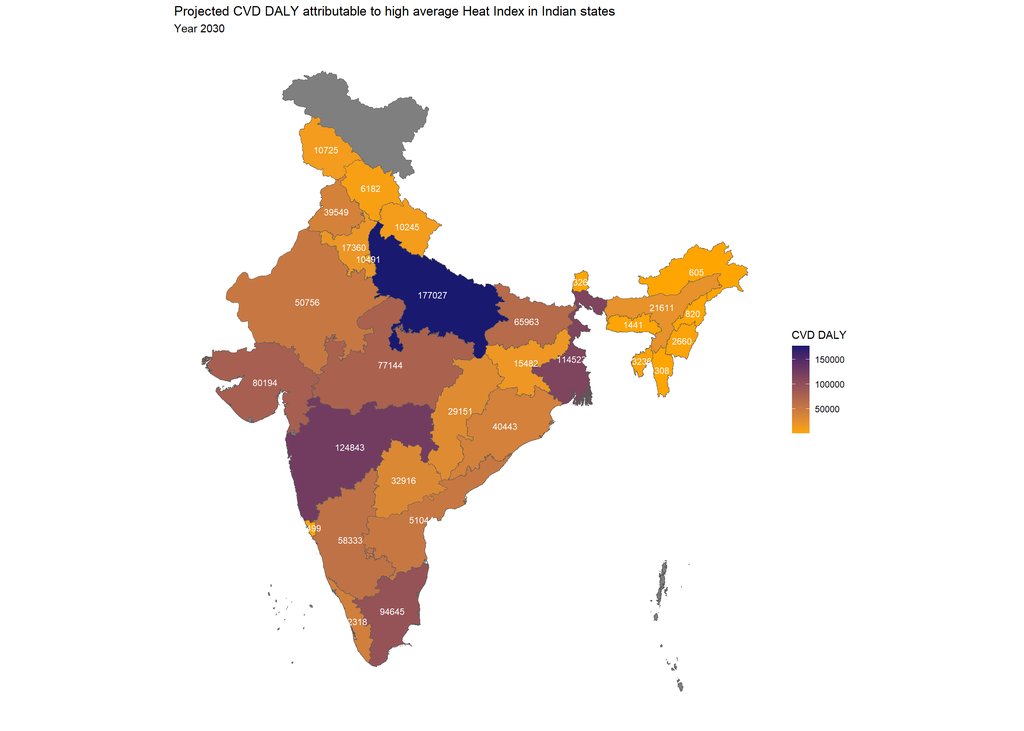

```r
# DALY map
india_paf_economy_2030 |>
  ggplot() +
  geom_sf(aes(fill = paf_daly_proj2030_avg975hi)) +
  scale_fill_gradient(low = "orange", high = "midnightblue") +
  # Add paf on the states as text with x and y coordinates
  geom_text(aes(x = x, y = y, label = paf_daly_proj2030_avg975hi), size = 3, color = "white") +
  labs(fill = "CVD DALY",
       title = "Projected CVD DALY attributable to high average Heat Index in Indian states",
       subtitle = "Year 2030") +
  theme_classic() +
  # Make x-axis and y-axis blank
  theme(axis.text.x = element_blank(),
        axis.text.y = element_blank(),
        axis.title.x = element_blank(),
        axis.title.y = element_blank(),
        axis.ticks = element_blank(),
        axis.line = element_blank())
```

Figure 7 *Projected state-wise distribution of cardiovascular disease (CVD) disability-adjusted life years (DALYs) attributable to high average Heat Index in India, 2030. DALY counts were projected using uncorrected Global Burden of Disease (GBD) 2021 data and multiplied with population-attributable fractions (PAFs) based on exposure–response estimates. Values are presented as total DALYs (not standardized per 100,000 population). States are color-coded according to the magnitude of Heat Index-attributable CVD DALYs, with darker shades indicating higher burden. Uttar Pradesh, Maharashtra, and West Bengal exhibited the highest values, reflecting both high DALY burden and high cost-per-case in these states.*

**Click here to view/hide the code**

```r
# import data from output/total-econ-burden-projections using here

totaleconBurden_2030_data <- readRDS(here::here("output","total-econ-burden-projections","heatindex_daly_totalburden_cvd_2030.rds"))
```

### Total economic burden attributable to high average Heat Index - 2030

**Click here to view/hide the code**

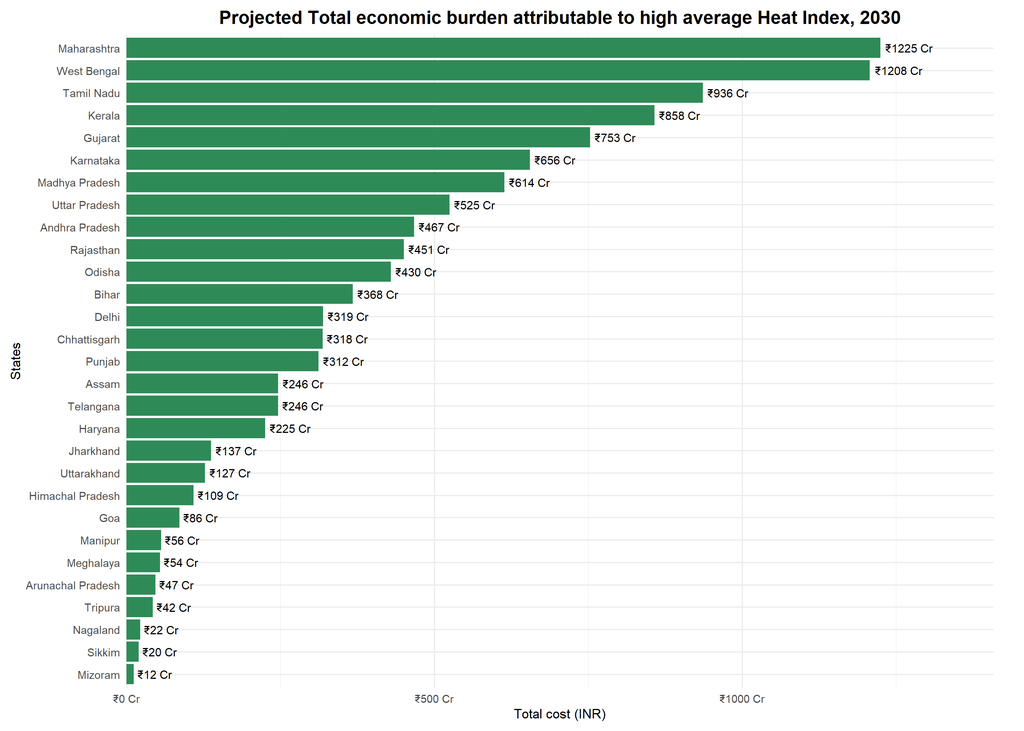

```r
#  visualize total econ burden in all states by bar charts



totaleconBurden_2030_data |>
  drop_na(totaleconBurden_2030) |>
  ggplot(aes(x = reorder(State, totaleconBurden_2030),
             y = totaleconBurden_2030)) +

  # Bar plot
  geom_bar(stat = "identity", fill = "seagreen") +

  # Label at the tail end, just outside the bar
  geom_text(aes(label = paste0("\u20B9", round(totaleconBurden_2030 / 1e7, 0), " Cr")),
            hjust = -0.1, color = "black", size = 4) +

  # Flip coordinates
  coord_flip(clip = "off") +  # allows text beyond plotting area

  # Titles and axis labels
  labs(
    title = "Projected Total economic burden attributable to high average Heat Index, 2030",
    x = "States",
    y = "Total cost (INR)"
  ) +

  # y-axis in crores
  scale_y_continuous(
    labels = function(x) paste0("\u20B9", x / 1e7, " Cr"),
    expand = expansion(mult = c(0, 0.15))  # space for tail labels
  ) +

  # Aesthetic theme
  theme_minimal(base_size = 14) +
  theme(
    plot.title = element_text(hjust = 0.5, size = 18, face = "bold"),
    axis.text.y = element_text(size = 11),
    axis.text.x = element_text(size = 11),
    axis.title.x = element_text(size = 13),
    axis.title.y = element_text(size = 13),
    plot.margin = margin(10, 30, 10, 10)  # top, right, bottom, left
  )
```

Figure 8 *Projected Total economic burden attributable to high average Heat Index across Indian states in 2030. This figure displays state-wise estimates of projected total economic burden (in Indian Rupees) linked to cardiovascular disease (CVD) disability-adjusted life years (DALYs) attributed to high average Heat Index. The projections in economic burden was computed by doing ARIMA models and multiplying absolute attributable DALY counts (from the GBD uncorrected dataset) with the estimated cost per DALY for 2030(projected). The highest costs were observed in Maharashtra,West Bengal and Tamil Nadu, reflecting both high DALY burden and high cost-per-case in these states.*

**Click here to view/hide the code**

```r
totaleconburden_2030_hi <- totaleconBurden_2030_data |>
  drop_na(totaleconBurden_2030) |>
  summarise(totaleconburden = sum(totaleconBurden_2030, na.rm = TRUE))


percentage_increase_inteb_hi <- ((totaleconburden_2030_hi$totaleconburden - totaleconburden_2021_hi$totaleconburden) / totaleconburden_2021_hi$totaleconburden) * 100
```

**Projected Total Economic Burden in 2030 in India due to High Average Heat Index**

There will be a total economic burden of **₹108 692 501 753** in 2030 due to high average Heat Index across Indian states. This estimate is based on the projections derived from **DALY** attributable to high average Heat Index and the cost per DALY.

**Projected Increase in Economic Burden from 2021 to 2030**

This reflects a projected increase of approximately **44.11**% in the total economic burden attributable to high average Heat Index across Indian states from 2021 to 2030.